# multimodal_gauss_plots slides

## Trying to match a mixture of two Gaussians with an MDN

- Fix $x > 0$ (we will take $x = 1$). We assume our target distribution $p$ is an equal mixture of two Gaussians with means $\pm x$ and variances $1$
- We approximate the target within the family $q(\lambda, \sigma^2)$, where $q(\lambda, \sigma^2)$ is an equal mixture of two Gaussians with means $\pm \lambda x$ and variances $\sigma^2$. Then $p=q(1, 1)$.
- We perform gradient descent on $\lambda$ and $\sigma$ in order to minimise $KL(p || q(\lambda, \sigma^2))$ or $KL(q(\lambda, \sigma^2) || p)$

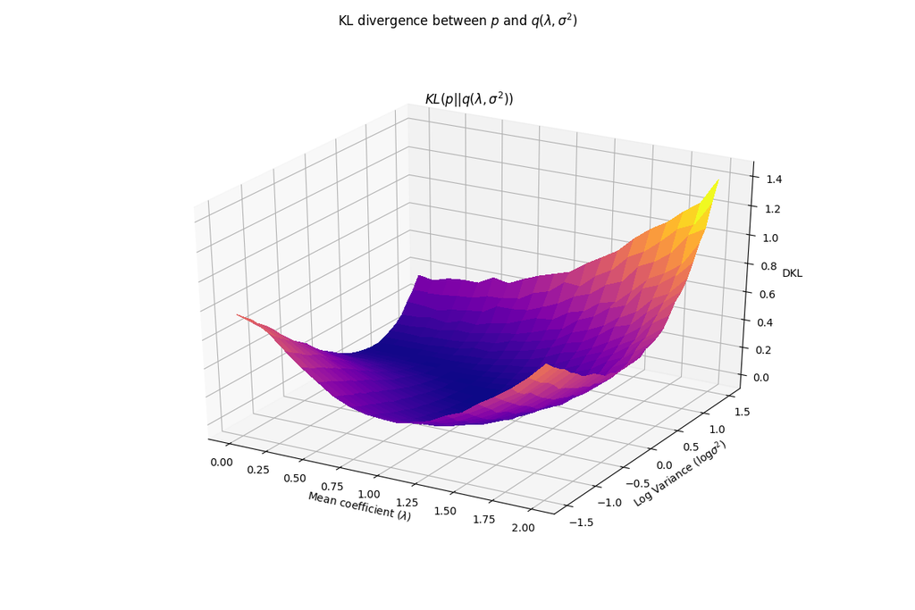

```python
plot_surface(with_reverse=False, penaliser=0);
```

- We see that $\lambda \simeq 0$ and $\sigma^2 \geq 2$ is is connected to ground truth by a flat valley
- If we start with $\lambda \simeq 0$, then gradient descent will end up in this valley, but not necessarily in the correct place
- If the two modes of $q(\lambda, \sigma^2)$ are too close, the result will likely be unimodal (bad)
- With SGD, small sample sizes will lead to an erratic descent, worsening the problem

## Adding a penaliser

- Formula for $KL$ divergence between two Gaussians contains the squared distance between two means
- If we added a regulariser which is equal to the (linear) distance between the two modes of $q$ (in our case: $2\lambda x$), we would penalise mode coalescence
- Quadratic term in DKL will ensure that the modes stay in a bounded region (finite separation)
- Problems: a) Need to choose prefactor associated to regulariser term b) Minimum shifts away from GT
- Second problem can be solved by adding final round without penaliser

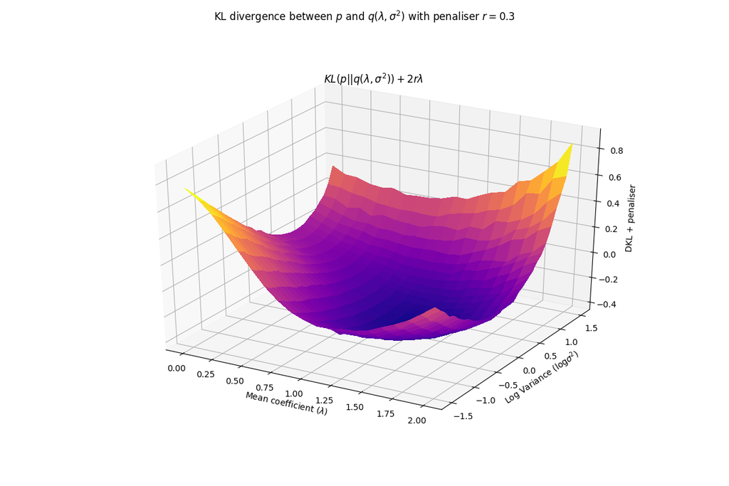

```python
plot_surface(with_reverse=False, penaliser=0.3);
```